# Risk Factor Analysis

## Outcome Variable

**Outcome Variable:** ever_stunted

## Predictor Variables

**Intervention Variable:** gagebrth

**Adjustment Set:**

unadjusted

## Stratifying Variables

The analysis was stratified on these variable(s):

- agecat
- studyid

The following strata were considered:

- agecat: 12 months, studyid: ki1000108-CMC-V-BCS-2002
- agecat: 12 months, studyid: ki1000108-IRC
- agecat: 12 months, studyid: ki1000109-EE
- agecat: 12 months, studyid: ki1000304b-SAS-CompFeed
- agecat: 12 months, studyid: ki1017093c-NIH-Crypto
- agecat: 12 months, studyid: ki1066203-TanzaniaChild2
- agecat: 12 months, studyid: ki1101329-Keneba
- agecat: 12 months, studyid: ki1113344-GMS-Nepal
- agecat: 12 months, studyid: ki1119695-PROBIT
- agecat: 12 months, studyid: ki1135781-COHORTS
- agecat: 12 months, studyid: kiGH5241-JiVitA-3
- agecat: 18 months, studyid: ki1000108-CMC-V-BCS-2002
- agecat: 18 months, studyid: ki1000108-IRC
- agecat: 18 months, studyid: ki1000109-EE
- agecat: 18 months, studyid: ki1000304b-SAS-CompFeed
- agecat: 18 months, studyid: ki1017093c-NIH-Crypto
- agecat: 18 months, studyid: ki1066203-TanzaniaChild2
- agecat: 18 months, studyid: ki1101329-Keneba
- agecat: 18 months, studyid: ki1113344-GMS-Nepal
- agecat: 18 months, studyid: ki1119695-PROBIT
- agecat: 18 months, studyid: ki1135781-COHORTS
- agecat: 18 months, studyid: kiGH5241-JiVitA-3
- agecat: 24 months, studyid: ki1000108-CMC-V-BCS-2002
- agecat: 24 months, studyid: ki1000108-IRC
- agecat: 24 months, studyid: ki1000109-EE
- agecat: 24 months, studyid: ki1000304b-SAS-CompFeed
- agecat: 24 months, studyid: ki1017093c-NIH-Crypto
- agecat: 24 months, studyid: ki1066203-TanzaniaChild2
- agecat: 24 months, studyid: ki1101329-Keneba
- agecat: 24 months, studyid: ki1113344-GMS-Nepal
- agecat: 24 months, studyid: ki1119695-PROBIT
- agecat: 24 months, studyid: ki1135781-COHORTS
- agecat: 24 months, studyid: kiGH5241-JiVitA-3
- agecat: 3 months, studyid: ki1000108-CMC-V-BCS-2002
- agecat: 3 months, studyid: ki1000108-IRC
- agecat: 3 months, studyid: ki1000109-EE
- agecat: 3 months, studyid: ki1000304b-SAS-CompFeed
- agecat: 3 months, studyid: ki1017093c-NIH-Crypto
- agecat: 3 months, studyid: ki1066203-TanzaniaChild2
- agecat: 3 months, studyid: ki1101329-Keneba
- agecat: 3 months, studyid: ki1113344-GMS-Nepal
- agecat: 3 months, studyid: ki1119695-PROBIT
- agecat: 3 months, studyid: ki1135781-COHORTS
- agecat: 3 months, studyid: kiGH5241-JiVitA-3
- agecat: 6 months, studyid: ki1000108-CMC-V-BCS-2002
- agecat: 6 months, studyid: ki1000108-IRC
- agecat: 6 months, studyid: ki1000109-EE
- agecat: 6 months, studyid: ki1000304b-SAS-CompFeed
- agecat: 6 months, studyid: ki1017093c-NIH-Crypto
- agecat: 6 months, studyid: ki1066203-TanzaniaChild2
- agecat: 6 months, studyid: ki1101329-Keneba
- agecat: 6 months, studyid: ki1113344-GMS-Nepal
- agecat: 6 months, studyid: ki1119695-PROBIT
- agecat: 6 months, studyid: ki1135781-COHORTS
- agecat: 6 months, studyid: kiGH5241-JiVitA-3

### Dropped Strata

Some strata were dropped due to rare outcomes:

- agecat: 12 months, studyid: ki1000109-EE
- agecat: 12 months, studyid: ki1000304b-SAS-CompFeed
- agecat: 12 months, studyid: ki1017093c-NIH-Crypto
- agecat: 12 months, studyid: ki1113344-GMS-Nepal
- agecat: 18 months, studyid: ki1000109-EE
- agecat: 18 months, studyid: ki1000304b-SAS-CompFeed
- agecat: 18 months, studyid: ki1017093c-NIH-Crypto
- agecat: 18 months, studyid: ki1113344-GMS-Nepal
- agecat: 24 months, studyid: ki1000108-CMC-V-BCS-2002
- agecat: 24 months, studyid: ki1000109-EE
- agecat: 24 months, studyid: ki1000304b-SAS-CompFeed
- agecat: 24 months, studyid: ki1017093c-NIH-Crypto
- agecat: 24 months, studyid: ki1113344-GMS-Nepal
- agecat: 24 months, studyid: kiGH5241-JiVitA-3
- agecat: 3 months, studyid: ki1000109-EE
- agecat: 3 months, studyid: ki1000304b-SAS-CompFeed
- agecat: 3 months, studyid: ki1017093c-NIH-Crypto
- agecat: 3 months, studyid: ki1113344-GMS-Nepal
- agecat: 6 months, studyid: ki1000109-EE
- agecat: 6 months, studyid: ki1000304b-SAS-CompFeed
- agecat: 6 months, studyid: ki1017093c-NIH-Crypto
- agecat: 6 months, studyid: ki1113344-GMS-Nepal

## Methods Detail

# Results Detail

## Results Plots

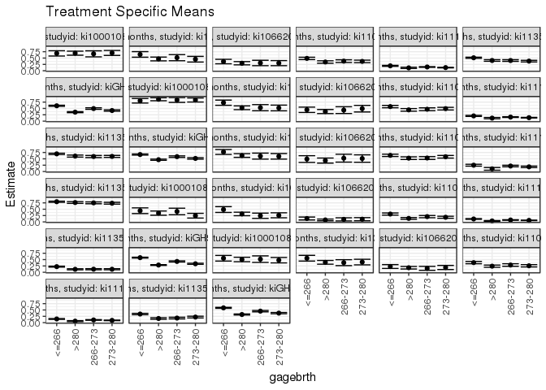

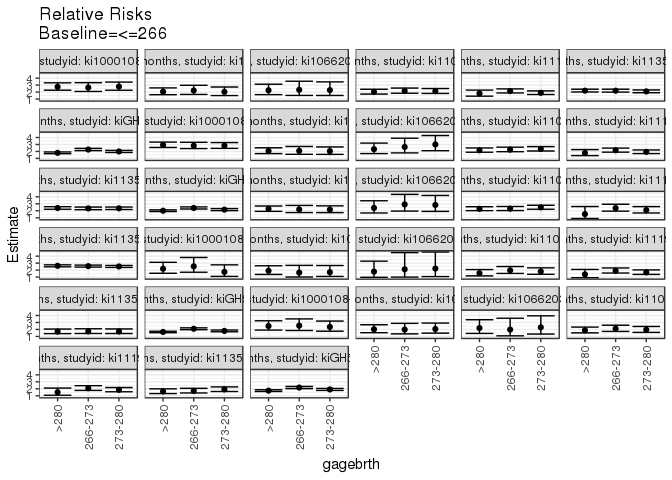

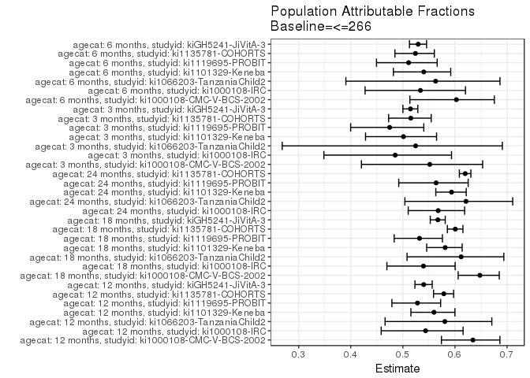

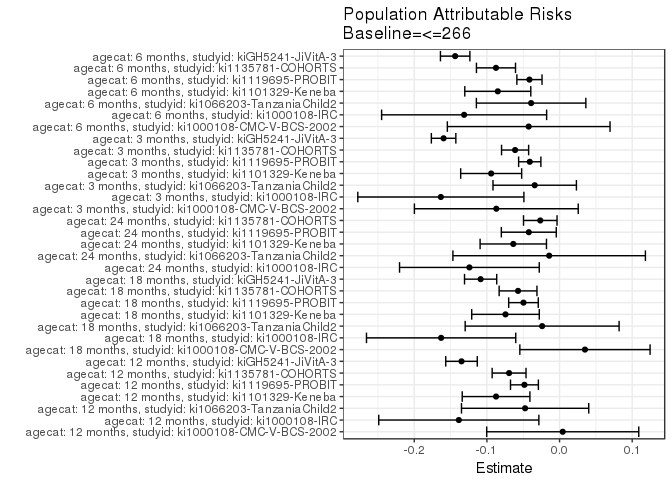

## Data Summary

| agecat | studyid | A | n | nA | nAY0 | nAY1 |
| --- | --- | --- | --- | --- | --- | --- |
| 12 months | ki1000108-CMC-V-BCS-2002 | <=266 | 350 | 76 | 24 | 52 |
| 12 months | ki1000108-CMC-V-BCS-2002 | >280 | 350 | 130 | 40 | 90 |
| 12 months | ki1000108-CMC-V-BCS-2002 | 266-273 | 350 | 60 | 20 | 40 |
| 12 months | ki1000108-CMC-V-BCS-2002 | 273-280 | 350 | 84 | 25 | 59 |
| 12 months | ki1000108-IRC | <=266 | 388 | 73 | 26 | 47 |
| 12 months | ki1000108-IRC | >280 | 388 | 172 | 92 | 80 |
| 12 months | ki1000108-IRC | 266-273 | 388 | 66 | 32 | 34 |
| 12 months | ki1000108-IRC | 273-280 | 388 | 77 | 42 | 35 |
| 12 months | ki1000109-EE | <=266 | 373 | 297 | 45 | 252 |
| 12 months | ki1000109-EE | >280 | 373 | 17 | 6 | 11 |
| 12 months | ki1000109-EE | 266-273 | 373 | 51 | 13 | 38 |
| 12 months | ki1000109-EE | 273-280 | 373 | 8 | 1 | 7 |
| 12 months | ki1000304b-SAS-CompFeed | <=266 | 886 | 854 | 350 | 504 |
| 12 months | ki1000304b-SAS-CompFeed | >280 | 886 | 3 | 1 | 2 |
| 12 months | ki1000304b-SAS-CompFeed | 266-273 | 886 | 13 | 8 | 5 |
| 12 months | ki1000304b-SAS-CompFeed | 273-280 | 886 | 16 | 8 | 8 |
| 12 months | ki1017093c-NIH-Crypto | <=266 | 729 | 729 | 452 | 277 |
| 12 months | ki1017093c-NIH-Crypto | >280 | 729 | 0 | 0 | 0 |
| 12 months | ki1017093c-NIH-Crypto | 266-273 | 729 | 0 | 0 | 0 |
| 12 months | ki1017093c-NIH-Crypto | 273-280 | 729 | 0 | 0 | 0 |
| 12 months | ki1066203-TanzaniaChild2 | <=266 | 464 | 116 | 74 | 42 |
| 12 months | ki1066203-TanzaniaChild2 | >280 | 464 | 196 | 138 | 58 |
| 12 months | ki1066203-TanzaniaChild2 | 266-273 | 464 | 72 | 50 | 22 |
| 12 months | ki1066203-TanzaniaChild2 | 273-280 | 464 | 80 | 56 | 24 |
| 12 months | ki1101329-Keneba | <=266 | 1521 | 444 | 228 | 216 |
| 12 months | ki1101329-Keneba | >280 | 1521 | 380 | 249 | 131 |
| 12 months | ki1101329-Keneba | 266-273 | 1521 | 325 | 202 | 123 |
| 12 months | ki1101329-Keneba | 273-280 | 1521 | 372 | 235 | 137 |
| 12 months | ki1113344-GMS-Nepal | <=266 | 582 | 1 | 0 | 1 |
| 12 months | ki1113344-GMS-Nepal | >280 | 582 | 4 | 3 | 1 |

[output cut: 190 more lines]

## Results Table

### Parameter: TSM

| agecat | studyid | intervention_level | baseline_level | estimate | ci_lower | ci_upper |
| --- | --- | --- | --- | --- | --- | --- |
| 12 months | ki1000108-CMC-V-BCS-2002 | <=266 | NA | 0.6842105 | 0.5795564 | 0.7888646 |
| 12 months | ki1000108-CMC-V-BCS-2002 | >280 | NA | 0.6923077 | 0.6128555 | 0.7717598 |
| 12 months | ki1000108-CMC-V-BCS-2002 | 266-273 | NA | 0.6666667 | 0.5472163 | 0.7861170 |
| 12 months | ki1000108-CMC-V-BCS-2002 | 273-280 | NA | 0.7023810 | 0.6044666 | 0.8002953 |
| 12 months | ki1000108-IRC | <=266 | NA | 0.6438356 | 0.5338439 | 0.7538273 |
| 12 months | ki1000108-IRC | >280 | NA | 0.4651163 | 0.3904792 | 0.5397534 |
| 12 months | ki1000108-IRC | 266-273 | NA | 0.5151515 | 0.3944238 | 0.6358792 |
| 12 months | ki1000108-IRC | 273-280 | NA | 0.4545455 | 0.3431850 | 0.5659059 |
| 12 months | ki1066203-TanzaniaChild2 | <=266 | NA | 0.3620690 | 0.2745162 | 0.4496218 |
| 12 months | ki1066203-TanzaniaChild2 | >280 | NA | 0.2959184 | 0.2319469 | 0.3598898 |
| 12 months | ki1066203-TanzaniaChild2 | 266-273 | NA | 0.3055556 | 0.1990397 | 0.4120714 |
| 12 months | ki1066203-TanzaniaChild2 | 273-280 | NA | 0.3000000 | 0.1994733 | 0.4005267 |
| 12 months | ki1101329-Keneba | <=266 | NA | 0.4864865 | 0.4399803 | 0.5329927 |
| 12 months | ki1101329-Keneba | >280 | NA | 0.3447368 | 0.2969343 | 0.3925394 |
| 12 months | ki1101329-Keneba | 266-273 | NA | 0.3784615 | 0.3257150 | 0.4312081 |
| 12 months | ki1101329-Keneba | 273-280 | NA | 0.3682796 | 0.3192486 | 0.4173106 |
| 12 months | ki1119695-PROBIT | <=266 | NA | 0.1940024 | 0.1748281 | 0.2131768 |
| 12 months | ki1119695-PROBIT | >280 | NA | 0.1141046 | 0.0892959 | 0.1389133 |
| 12 months | ki1119695-PROBIT | 266-273 | NA | 0.1483495 | 0.1346198 | 0.1620792 |
| 12 months | ki1119695-PROBIT | 273-280 | NA | 0.1243957 | 0.1127828 | 0.1360087 |
| 12 months | ki1135781-COHORTS | <=266 | NA | 0.5112613 | 0.4880106 | 0.5345119 |
| 12 months | ki1135781-COHORTS | >280 | NA | 0.4045802 | 0.3728095 | 0.4363508 |
| 12 months | ki1135781-COHORTS | 266-273 | NA | 0.4028436 | 0.3697505 | 0.4359367 |
| 12 months | ki1135781-COHORTS | 273-280 | NA | 0.3794248 | 0.3477894 | 0.4110601 |
| 12 months | kiGH5241-JiVitA-3 | <=266 | NA | 0.6041456 | 0.5825926 | 0.6256986 |
| 12 months | kiGH5241-JiVitA-3 | >280 | NA | 0.3534953 | 0.3326308 | 0.3743598 |
| 12 months | kiGH5241-JiVitA-3 | 266-273 | NA | 0.4953096 | 0.4652934 | 0.5253257 |
| 12 months | kiGH5241-JiVitA-3 | 273-280 | NA | 0.4178482 | 0.3899292 | 0.4457673 |
| 18 months | ki1000108-CMC-V-BCS-2002 | <=266 | NA | 0.8026316 | 0.7130213 | 0.8922418 |
| 18 months | ki1000108-CMC-V-BCS-2002 | >280 | NA | 0.8625954 | 0.8035568 | 0.9216340 |

[output cut: 102 more lines]

### Parameter: E(Y)

| agecat | studyid | intervention_level | baseline_level | estimate | ci_lower | ci_upper |
| --- | --- | --- | --- | --- | --- | --- |
| 12 months | ki1000108-CMC-V-BCS-2002 | NA | NA | 0.6885714 | 0.6873419 | 0.6898009 |
| 12 months | ki1000108-IRC | NA | NA | 0.5051546 | 0.4982130 | 0.5120963 |
| 12 months | ki1066203-TanzaniaChild2 | NA | NA | 0.3146552 | 0.3121438 | 0.3171666 |
| 12 months | ki1101329-Keneba | NA | NA | 0.3990796 | 0.3961957 | 0.4019635 |
| 12 months | ki1119695-PROBIT | NA | NA | 0.1456628 | 0.1450650 | 0.1462607 |
| 12 months | ki1135781-COHORTS | NA | NA | 0.4417924 | 0.4401037 | 0.4434811 |
| 12 months | kiGH5241-JiVitA-3 | NA | NA | 0.4691693 | 0.4666080 | 0.4717306 |
| 18 months | ki1000108-CMC-V-BCS-2002 | NA | NA | 0.8376068 | 0.8352516 | 0.8399621 |
| 18 months | ki1000108-IRC | NA | NA | 0.5629820 | 0.5551774 | 0.5707867 |
| 18 months | ki1066203-TanzaniaChild2 | NA | NA | 0.4230769 | 0.4185214 | 0.4276325 |
| 18 months | ki1101329-Keneba | NA | NA | 0.4989817 | 0.4963718 | 0.5015915 |
| 18 months | ki1119695-PROBIT | NA | NA | 0.1565217 | 0.1558880 | 0.1571555 |
| 18 months | ki1135781-COHORTS | NA | NA | 0.6385460 | 0.6367926 | 0.6402994 |
| 18 months | kiGH5241-JiVitA-3 | NA | NA | 0.5600940 | 0.5578785 | 0.5623095 |
| 24 months | ki1000108-IRC | NA | NA | 0.6461538 | 0.6400448 | 0.6522629 |
| 24 months | ki1066203-TanzaniaChild2 | NA | NA | 0.4765957 | 0.4716432 | 0.4815483 |
| 24 months | ki1101329-Keneba | NA | NA | 0.5733057 | 0.5709210 | 0.5756903 |
| 24 months | ki1119695-PROBIT | NA | NA | 0.2061657 | 0.2046376 | 0.2076938 |
| 24 months | ki1135781-COHORTS | NA | NA | 0.7682073 | 0.7673325 | 0.7690821 |
| 3 months | ki1000108-CMC-V-BCS-2002 | NA | NA | 0.3529412 | 0.3453355 | 0.3605468 |
| 3 months | ki1000108-IRC | NA | NA | 0.3230769 | 0.3147552 | 0.3313986 |
| 3 months | ki1066203-TanzaniaChild2 | NA | NA | 0.0991150 | 0.0972750 | 0.1009551 |
| 3 months | ki1101329-Keneba | NA | NA | 0.2150193 | 0.2117256 | 0.2183129 |
| 3 months | ki1119695-PROBIT | NA | NA | 0.0740923 | 0.0735901 | 0.0745945 |
| 3 months | ki1135781-COHORTS | NA | NA | 0.1606654 | 0.1592308 | 0.1621000 |
| 3 months | kiGH5241-JiVitA-3 | NA | NA | 0.4162928 | 0.4138886 | 0.4186969 |
| 6 months | ki1000108-CMC-V-BCS-2002 | NA | NA | 0.5101449 | 0.5073470 | 0.5129428 |
| 6 months | ki1000108-IRC | NA | NA | 0.4226804 | 0.4162859 | 0.4290749 |
| 6 months | ki1066203-TanzaniaChild2 | NA | NA | 0.1877395 | 0.1857113 | 0.1897676 |
| 6 months | ki1101329-Keneba | NA | NA | 0.2959184 | 0.2929644 | 0.2988723 |
| 6 months | ki1119695-PROBIT | NA | NA | 0.1042654 | 0.1037251 | 0.1048057 |
| 6 months | ki1135781-COHORTS | NA | NA | 0.2524373 | 0.2496335 | 0.2552411 |
| 6 months | kiGH5241-JiVitA-3 | NA | NA | 0.4396636 | 0.4371386 | 0.4421887 |

### Parameter: RR

| agecat | studyid | intervention_level | baseline_level | estimate | ci_lower | ci_upper |
| --- | --- | --- | --- | --- | --- | --- |
| 12 months | ki1000108-CMC-V-BCS-2002 | >280 | <=266 | 2.750642 | 2.2718875 | 3.330284 |
| 12 months | ki1000108-CMC-V-BCS-2002 | 266-273 | <=266 | 2.649468 | 2.0933713 | 3.353291 |
| 12 months | ki1000108-CMC-V-BCS-2002 | 273-280 | <=266 | 2.791438 | 2.2696040 | 3.433253 |
| 12 months | ki1000108-IRC | >280 | <=266 | 2.059400 | 1.6291036 | 2.603351 |
| 12 months | ki1000108-IRC | 266-273 | <=266 | 2.225828 | 1.6654848 | 2.974696 |
| 12 months | ki1000108-IRC | 273-280 | <=266 | 2.025864 | 1.5027854 | 2.731011 |
| 12 months | ki1066203-TanzaniaChild2 | >280 | <=266 | 2.264374 | 1.6371262 | 3.131945 |
| 12 months | ki1066203-TanzaniaChild2 | 266-273 | <=266 | 2.325454 | 1.5214428 | 3.554348 |
| 12 months | ki1066203-TanzaniaChild2 | 273-280 | <=266 | 2.290045 | 1.5148901 | 3.461839 |
| 12 months | ki1101329-Keneba | >280 | <=266 | 2.031198 | 1.7163550 | 2.403795 |
| 12 months | ki1101329-Keneba | 266-273 | <=266 | 2.177002 | 1.8384874 | 2.577846 |
| 12 months | ki1101329-Keneba | 273-280 | <=266 | 2.131912 | 1.8096219 | 2.511601 |
| 12 months | ki1119695-PROBIT | >280 | <=266 | 1.800673 | 1.4181170 | 2.286429 |
| 12 months | ki1119695-PROBIT | 266-273 | <=266 | 2.148304 | 1.8762516 | 2.459803 |
| 12 months | ki1119695-PROBIT | 273-280 | <=266 | 1.898772 | 1.6574047 | 2.175288 |
| 12 months | ki1135781-COHORTS | >280 | <=266 | 2.206345 | 2.0149452 | 2.415926 |
| 12 months | ki1135781-COHORTS | 266-273 | <=266 | 2.198864 | 2.0017945 | 2.415334 |
| 12 months | ki1135781-COHORTS | 273-280 | <=266 | 2.100415 | 1.9101114 | 2.309678 |
| 12 months | kiGH5241-JiVitA-3 | >280 | <=266 | 1.795199 | 1.6755623 | 1.923379 |
| 12 months | kiGH5241-JiVitA-3 | 266-273 | <=266 | 2.270162 | 2.1160039 | 2.435552 |
| 12 months | kiGH5241-JiVitA-3 | 273-280 | <=266 | 1.996978 | 1.8513055 | 2.154113 |
| 18 months | ki1000108-CMC-V-BCS-2002 | >280 | <=266 | 2.929140 | 2.5696101 | 3.338975 |
| 18 months | ki1000108-CMC-V-BCS-2002 | 266-273 | <=266 | 2.824274 | 2.4089048 | 3.311266 |
| 18 months | ki1000108-CMC-V-BCS-2002 | 273-280 | <=266 | 2.824274 | 2.4379450 | 3.271823 |
| 18 months | ki1000108-IRC | >280 | <=266 | 2.063712 | 1.6897547 | 2.520430 |
| 18 months | ki1000108-IRC | 266-273 | <=266 | 2.075947 | 1.5885908 | 2.712817 |
| 18 months | ki1000108-IRC | 273-280 | <=266 | 2.045231 | 1.5813290 | 2.645225 |
| 18 months | ki1066203-TanzaniaChild2 | >280 | <=266 | 2.327237 | 1.6950505 | 3.195203 |
| 18 months | ki1066203-TanzaniaChild2 | 266-273 | <=266 | 2.639805 | 1.7900937 | 3.892853 |
| 18 months | ki1066203-TanzaniaChild2 | 273-280 | <=266 | 3.000562 | 2.1037772 | 4.279623 |

[output cut: 69 more lines]

### Parameter: PAR

| agecat | studyid | intervention_level | baseline_level | estimate | ci_lower | ci_upper |
| --- | --- | --- | --- | --- | --- | --- |
| 12 months | ki1000108-CMC-V-BCS-2002 | <=266 | NA | 0.0043609 | -0.1003004 | 0.1090222 |
| 12 months | ki1000108-IRC | <=266 | NA | -0.1386810 | -0.2488915 | -0.0284705 |
| 12 months | ki1066203-TanzaniaChild2 | <=266 | NA | -0.0474138 | -0.1350026 | 0.0401750 |
| 12 months | ki1101329-Keneba | <=266 | NA | -0.0874069 | -0.1340025 | -0.0408114 |
| 12 months | ki1119695-PROBIT | <=266 | NA | -0.0483396 | -0.0675232 | -0.0291560 |
| 12 months | ki1135781-COHORTS | <=266 | NA | -0.0694689 | -0.0927808 | -0.0461570 |
| 12 months | kiGH5241-JiVitA-3 | <=266 | NA | -0.1349763 | -0.1566809 | -0.1132716 |
| 18 months | ki1000108-CMC-V-BCS-2002 | <=266 | NA | 0.0349753 | -0.0546660 | 0.1246165 |
| 18 months | ki1000108-IRC | <=266 | NA | -0.1630454 | -0.2657837 | -0.0603071 |
| 18 months | ki1066203-TanzaniaChild2 | <=266 | NA | -0.0239819 | -0.1299330 | 0.0819692 |
| 18 months | ki1101329-Keneba | <=266 | NA | -0.0744128 | -0.1209261 | -0.0278995 |
| 18 months | ki1119695-PROBIT | <=266 | NA | -0.0496706 | -0.0700338 | -0.0293074 |
| 18 months | ki1135781-COHORTS | <=266 | NA | -0.0571423 | -0.0831740 | -0.0311105 |
| 18 months | kiGH5241-JiVitA-3 | <=266 | NA | -0.1086667 | -0.1308248 | -0.0865086 |
| 24 months | ki1000108-IRC | <=266 | NA | -0.1241164 | -0.2202772 | -0.0279556 |
| 24 months | ki1066203-TanzaniaChild2 | <=266 | NA | -0.0143133 | -0.1468068 | 0.1181802 |
| 24 months | ki1101329-Keneba | <=266 | NA | -0.0636967 | -0.1093844 | -0.0180090 |
| 24 months | ki1119695-PROBIT | <=266 | NA | -0.0423432 | -0.0801489 | -0.0045376 |
| 24 months | ki1135781-COHORTS | <=266 | NA | -0.0265340 | -0.0496091 | -0.0034589 |
| 3 months | ki1000108-CMC-V-BCS-2002 | <=266 | NA | -0.0870588 | -0.1998221 | 0.0257044 |
| 3 months | ki1000108-IRC | <=266 | NA | -0.1634096 | -0.2777381 | -0.0490810 |
| 3 months | ki1066203-TanzaniaChild2 | <=266 | NA | -0.0342183 | -0.0916411 | 0.0232045 |
| 3 months | ki1101329-Keneba | <=266 | NA | -0.0941492 | -0.1361180 | -0.0521804 |
| 3 months | ki1119695-PROBIT | <=266 | NA | -0.0410156 | -0.0563409 | -0.0256903 |
| 3 months | ki1135781-COHORTS | <=266 | NA | -0.0612096 | -0.0798524 | -0.0425668 |
| 3 months | kiGH5241-JiVitA-3 | <=266 | NA | -0.1596266 | -0.1764803 | -0.1427729 |
| 6 months | ki1000108-CMC-V-BCS-2002 | <=266 | NA | -0.0424867 | -0.1544711 | 0.0694978 |
| 6 months | ki1000108-IRC | <=266 | NA | -0.1313736 | -0.2449529 | -0.0177943 |
| 6 months | ki1066203-TanzaniaChild2 | <=266 | NA | -0.0391513 | -0.1145002 | 0.0361977 |
| 6 months | ki1101329-Keneba | <=266 | NA | -0.0850340 | -0.1304693 | -0.0395987 |
| 6 months | ki1119695-PROBIT | <=266 | NA | -0.0414507 | -0.0587535 | -0.0241478 |
| 6 months | ki1135781-COHORTS | <=266 | NA | -0.0875295 | -0.1144155 | -0.0606435 |
| 6 months | kiGH5241-JiVitA-3 | <=266 | NA | -0.1437058 | -0.1639738 | -0.1234378 |

### Parameter: PAF

| agecat | studyid | intervention_level | baseline_level | estimate | ci_lower | ci_upper |
| --- | --- | --- | --- | --- | --- | --- |
| 12 months | ki1000108-CMC-V-BCS-2002 | <=266 | NA | 0.6344578 | 0.5740389 | 0.6863069 |
| 12 months | ki1000108-IRC | <=266 | NA | 0.5436987 | 0.4583916 | 0.6155693 |
| 12 months | ki1066203-TanzaniaChild2 | <=266 | NA | 0.5806493 | 0.4658633 | 0.6707677 |
| 12 months | ki1101329-Keneba | <=266 | NA | 0.5597137 | 0.5154145 | 0.5999633 |
| 12 months | ki1119695-PROBIT | <=266 | NA | 0.5280253 | 0.4789500 | 0.5724784 |
| 12 months | ki1135781-COHORTS | <=266 | NA | 0.5785788 | 0.5589006 | 0.5973791 |
| 12 months | kiGH5241-JiVitA-3 | <=266 | NA | 0.5400250 | 0.5231211 | 0.5563298 |
| 18 months | ki1000108-CMC-V-BCS-2002 | <=266 | NA | 0.6478069 | 0.6061932 | 0.6850233 |
| 18 months | ki1000108-IRC | <=266 | NA | 0.5394934 | 0.4693487 | 0.6003659 |
| 18 months | ki1066203-TanzaniaChild2 | <=266 | NA | 0.6118472 | 0.5080286 | 0.6937574 |
| 18 months | ki1101329-Keneba | <=266 | NA | 0.5811423 | 0.5457302 | 0.6137939 |
| 18 months | ki1119695-PROBIT | <=266 | NA | 0.5319150 | 0.4833099 | 0.5759478 |
| 18 months | ki1135781-COHORTS | <=266 | NA | 0.6006281 | 0.5853945 | 0.6153020 |
| 18 months | kiGH5241-JiVitA-3 | <=266 | NA | 0.5672133 | 0.5526020 | 0.5813474 |
| 24 months | ki1000108-IRC | <=266 | NA | 0.5677998 | 0.5102793 | 0.6185642 |
| 24 months | ki1066203-TanzaniaChild2 | <=266 | NA | 0.6212365 | 0.5038800 | 0.7108324 |
| 24 months | ki1101329-Keneba | <=266 | NA | 0.5934326 | 0.5631912 | 0.6215803 |
| 24 months | ki1119695-PROBIT | <=266 | NA | 0.5637810 | 0.4920766 | 0.6253627 |
| 24 months | ki1135781-COHORTS | <=266 | NA | 0.6196308 | 0.6084245 | 0.6305165 |
| 3 months | ki1000108-CMC-V-BCS-2002 | <=266 | NA | 0.5516311 | 0.4204690 | 0.6531081 |
| 3 months | ki1000108-IRC | <=266 | NA | 0.4852647 | 0.3483882 | 0.5933892 |
| 3 months | ki1066203-TanzaniaChild2 | <=266 | NA | 0.5244878 | 0.2683938 | 0.6909378 |
| 3 months | ki1101329-Keneba | <=266 | NA | 0.5011631 | 0.4283814 | 0.5646778 |
| 3 months | ki1119695-PROBIT | <=266 | NA | 0.4746428 | 0.3997672 | 0.5401781 |
| 3 months | ki1135781-COHORTS | <=266 | NA | 0.5152518 | 0.4726424 | 0.5544185 |
| 3 months | kiGH5241-JiVitA-3 | <=266 | NA | 0.5146241 | 0.5000748 | 0.5287500 |
| 6 months | ki1000108-CMC-V-BCS-2002 | <=266 | NA | 0.6027222 | 0.5134764 | 0.6755971 |
| 6 months | ki1000108-IRC | <=266 | NA | 0.5336816 | 0.4274508 | 0.6202023 |
| 6 months | ki1066203-TanzaniaChild2 | <=266 | NA | 0.5628349 | 0.3906091 | 0.6863863 |
| 6 months | ki1101329-Keneba | <=266 | NA | 0.5401182 | 0.4817784 | 0.5918902 |
| 6 months | ki1119695-PROBIT | <=266 | NA | 0.5110711 | 0.4493958 | 0.5658378 |
| 6 months | ki1135781-COHORTS | <=266 | NA | 0.5240941 | 0.4847494 | 0.5604344 |
| 6 months | kiGH5241-JiVitA-3 | <=266 | NA | 0.5293603 | 0.5126219 | 0.5455239 |